# Dunlop growth rates - habitat

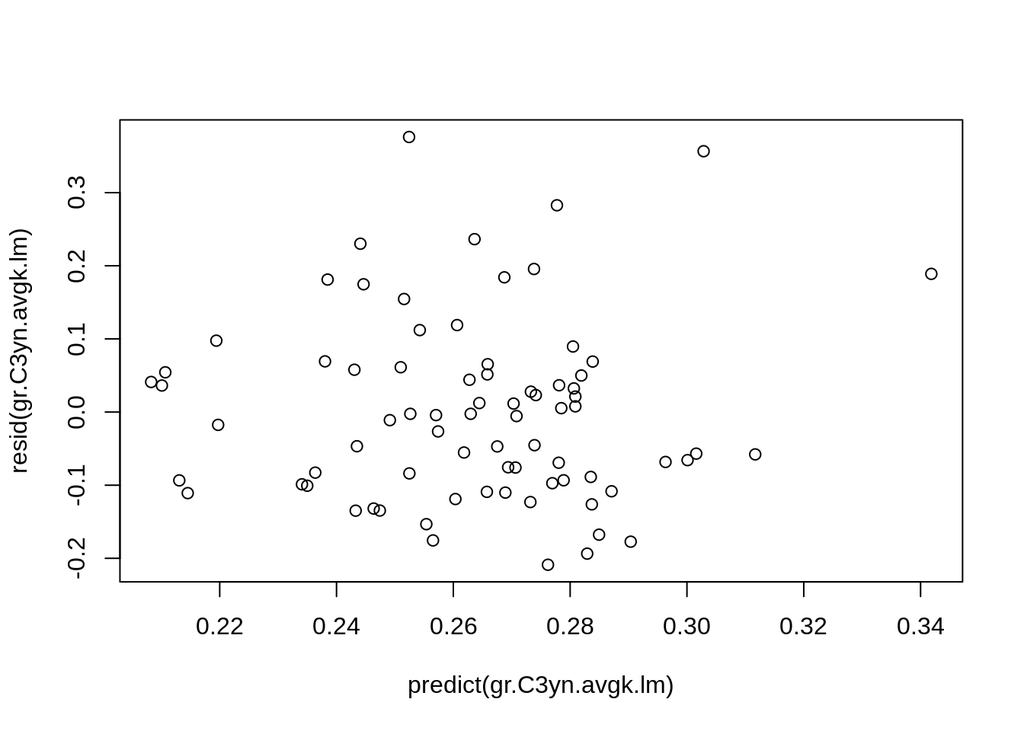

```r
plot(predict(gr.C3yn.avgk.lm), resid(gr.C3yn.avgk.lm)) # evaluate assumption of homoskedasticity
```

```r
# P value
summary(gr.C3yn.avgk.lm)$coefficients[2,4]
```

```
## [1] 0.09315551
```

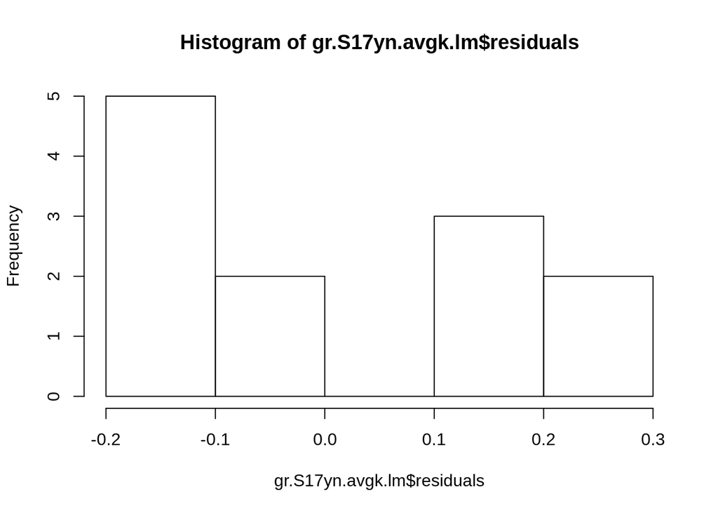

```r
# Successional C-amended vs water
gr.S17yn.avgk = inner_join(gr.S17y.avgk, gr.S17n.avgk, by="ASV")
gr.S17yn.avgk.lm = lm(S17y.avgk ~ S17n.avgk, data=gr.S17yn.avgk)

# Evaluate assumptions of linear regression
hist(gr.S17yn.avgk.lm$residuals) # evaluate assumption of normality
```

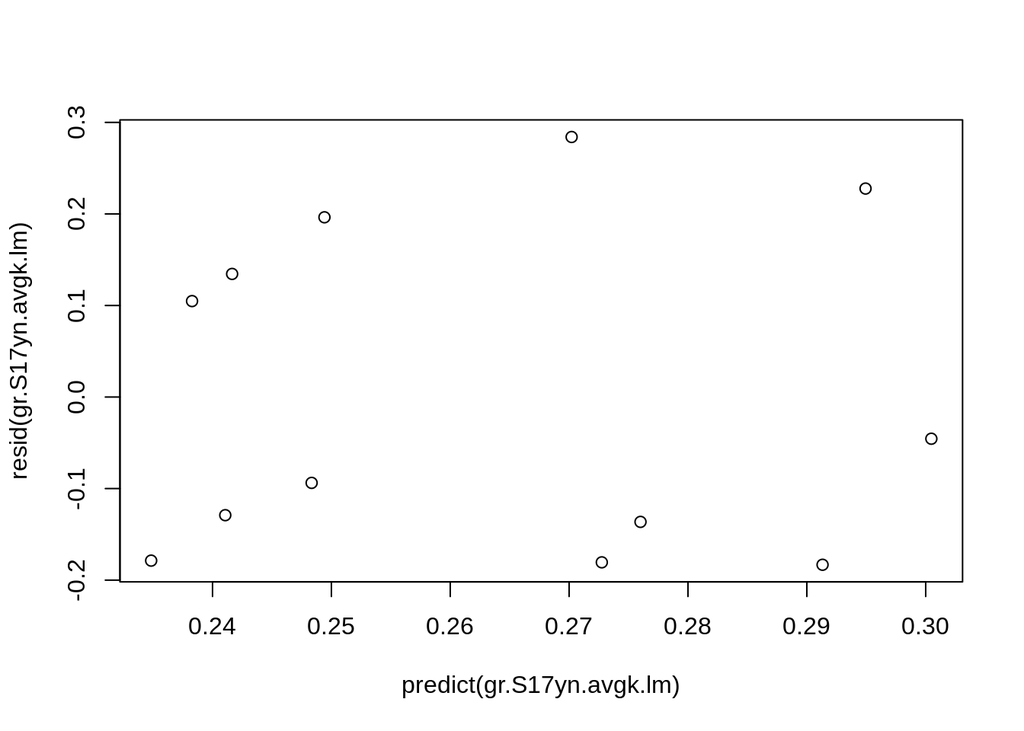

```r
plot(predict(gr.S17yn.avgk.lm), resid(gr.S17yn.avgk.lm)) # evaluate assumption of homoskedasticity
```

```r
# P value
summary(gr.S17yn.avgk.lm)$coefficients[2,4]
```

```
## [1] 0.6783426
```

Assumptions look fine, but the successional overlap data is just sparse. Anyways, nothing is significant.

# Explore bimodal distributions

The growth rate distribution graphs show distinct bimodal distributions in the water treatment. This seems to indicate differing populations, which I want to explore further.

Split data into “fast” and “slow” groups based on the bimodal distributions.

**Split by the bimodal distributions in unamended soils:**

Choose thresholds for each soil:

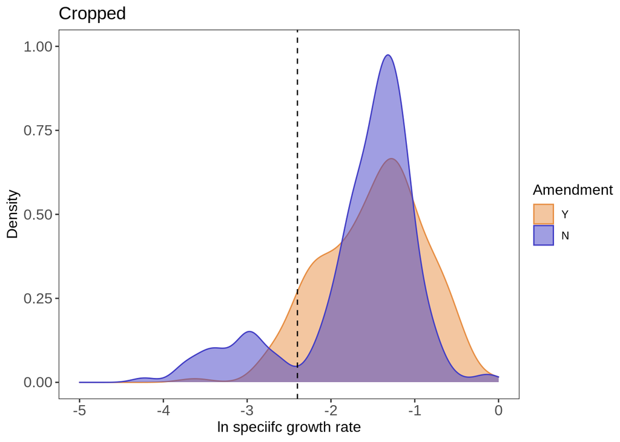

```r
gr.estavg %>%
  filter(Soil=="C3") %>%
  ggplot(aes(x=log(avgk), color=Amendment, fill=Amendment)) +
  geom_density(alpha=0.5) +
  theme_test() +
  theme(#legend.position="none",
        title=element_text(size=12),
        axis.text=element_text(size=12),
        axis.title=element_text(size=12)) +
  scale_color_manual(values=c("#E78E43", "#423EC5")) +
  scale_fill_manual(values=c("#E78E43", "#423EC5")) +
  labs(title="Cropped", x="ln speciifc growth rate", y="Density") +
  scale_y_continuous(limits=c(0,1)) +
  scale_x_continuous(limits=c(-5,0)) +
  geom_vline(xintercept=-2.4, linetype=2)
```

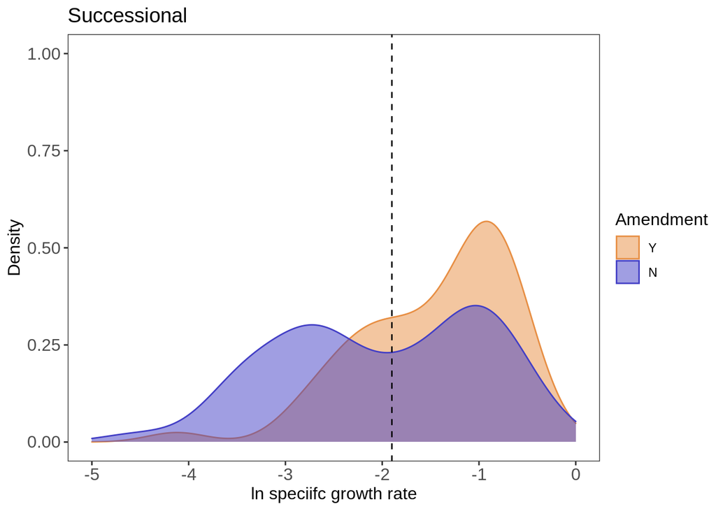

```r
gr.estavg %>%
  filter(Soil=="S17") %>%
  ggplot(aes(x=log(avgk), color=Amendment, fill=Amendment)) +
  geom_density(alpha=0.5) +
  theme_test() +
  theme(#legend.position="none",
        title=element_text(size=12),
        axis.text=element_text(size=12),
        axis.title=element_text(size=12)) +
  scale_color_manual(values=c("#E78E43", "#423EC5")) +
  scale_fill_manual(values=c("#E78E43", "#423EC5")) +
  labs(title="Successional", x="ln speciifc growth rate", y="Density") +
  scale_y_continuous(limits=c(0,1)) +
  scale_x_continuous(limits=c(-5,0)) +
  geom_vline(xintercept=-1.9, linetype=2)
```

Label ASVs based on avg growth rate threshold:

```r
# Water only
gr.asvgroup = gr.estavg %>%
  filter(Amendment=="N") %>%
  mutate(group = ifelse(Soil=="C3" & log(avgk) < -2.4, "slow", ifelse(Soil=="S17" & log(avgk) < -1.9, "slow", "fast")))

gr.asvgroup = gr.asvgroup[,c(1,3:ncol(gr.asvgroup))]
```

### Abundances of groups in field communities

Do these taxa exist in the in-field community data? If so, what are they’re abundances? I.e. did the soil shape the growth dynamics we observed in the microcosms?

Hypothesis: abundances of slow and fast taxa within field communities differ between cropped and successional soils.

Import field data:

```r
# Import data
field = readRDS("rdata.files/field.norm.cleaned.rds")

# Add group labels
field.group = field %>%
  inner_join(gr.asvgroup, var=c("Soil", "ASV", "Domain", "Phylum", "Class", "Order", "Family", "Genus",)) %>%
  filter(!norm_abund==0) %>% # remove 0 values, ie ASV not present
  mutate(group = parse_factor(group, levels=c("slow", "fast"))) # more intuitive order for groups
```

#### Individual ASV normalized abundances in each group:

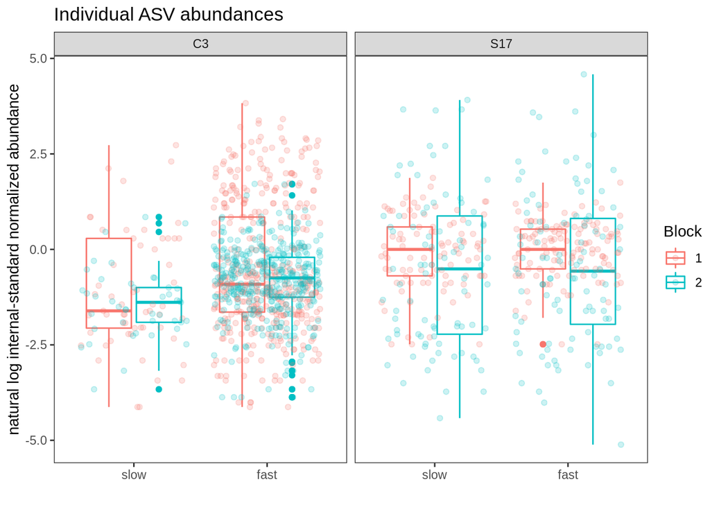

```r
# Visualize
field.group %>%
  ggplot(aes(x=group, y=log(norm_abund), color=as.factor(Block))) +
  geom_boxplot() +
  geom_jitter(alpha=0.2) +
  facet_wrap(~Soil) +
  labs(title="Individual ASV abundances", x="", y="natural log internal-standard normalized abundance", color="Block") +
  theme_test()
```

**Statistics**

Linear-mixed effects model

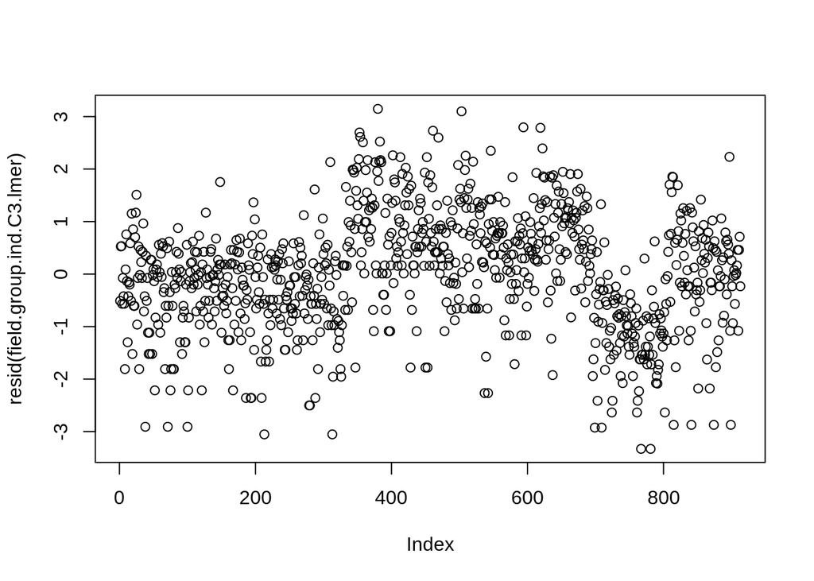

```r
# Cropped
field.group.ind.C3.lmer = lmer(log(norm_abund) ~ group + Block + (1|Replicate), data=field.group[field.group$Soil=="C3",]) # fit model
plot(resid(field.group.ind.C3.lmer)) # check normality
```

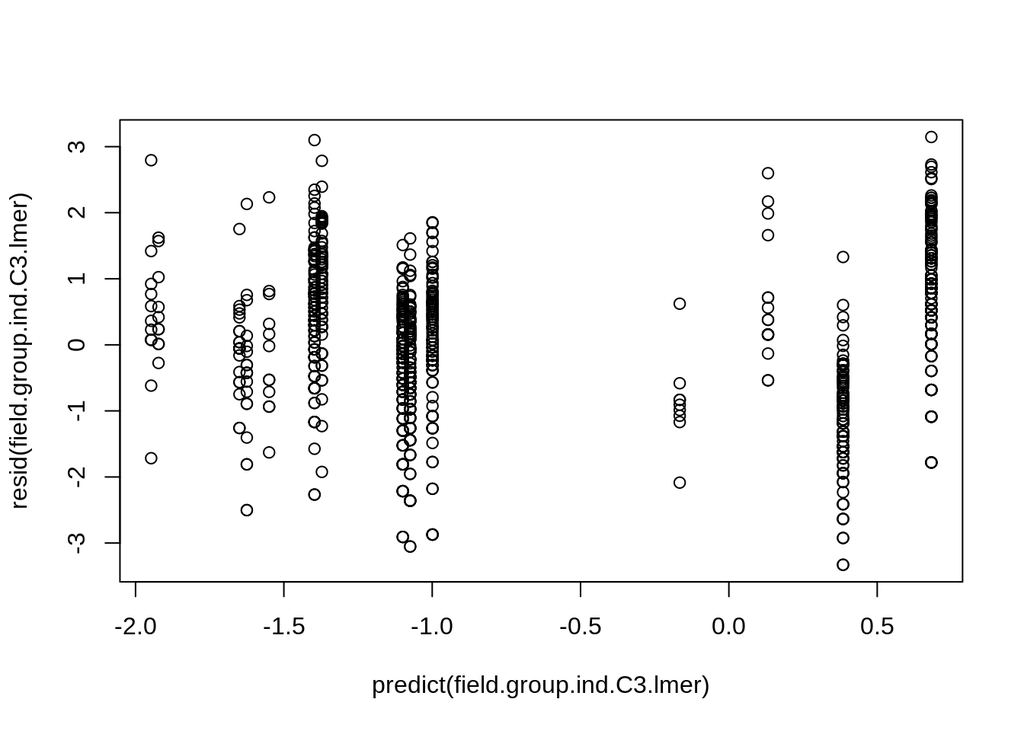

```r
plot(predict(field.group.ind.C3.lmer), resid(field.group.ind.C3.lmer)) # check variances
```

```r
anova(field.group.ind.C3.lmer) # results
```

```
## Type III Analysis of Variance Table with Satterthwaite's method
##       Sum Sq Mean Sq NumDF  DenDF F value    Pr(>F)
## group 26.950  26.950     1 907.03  21.747 3.578e-06 ***
## Block 16.859  16.859     1 909.85  13.604  0.000239 ***
## ---
## Signif. codes:  0 '***' 0.001 '**' 0.01 '*' 0.05 '.' 0.1 ' ' 1
```

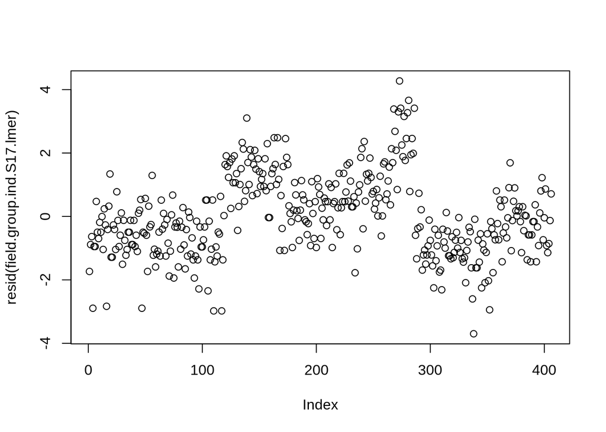

```r
# Successional
field.group.ind.S17.lmer = lmer(log(norm_abund) ~ group + Block + (1|Replicate), data=field.group[field.group$Soil=="S17",]) # fit model
plot(resid(field.group.ind.S17.lmer)) # check normality
```

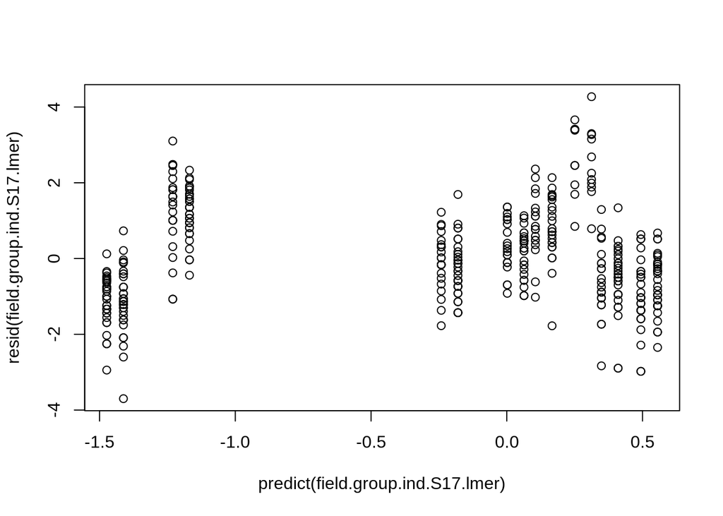

```r
plot(predict(field.group.ind.S17.lmer), resid(field.group.ind.S17.lmer)) # check variances
```

```r
anova(field.group.ind.S17.lmer) # results
```

```
## Type III Analysis of Variance Table with Satterthwaite's method
##       Sum Sq Mean Sq NumDF  DenDF F value  Pr(>F)
## group 0.3769  0.3769     1 400.04  0.2323 0.63011
## Block 5.6536  5.6536     1 401.02  3.4842 0.06269 .
## ---
## Signif. codes:  0 '***' 0.001 '**' 0.01 '*' 0.05 '.' 0.1 ' ' 1
```

#### Total, aggregated abundances in each group:

```r
# Sum abundances in each group
field.group.sum = field.group %>%
  group_by(Soil, Block, Replicate, group) %>%
  summarize(total_abund = sum(norm_abund))
```

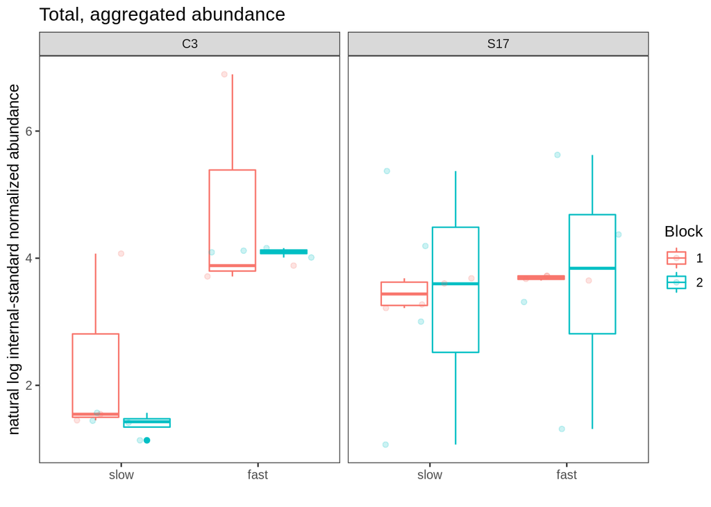

```r
# Visualize
field.group.sum %>%
  ggplot(aes(x=group, y=log(total_abund), color=as.factor(Block))) +
  geom_boxplot() +
  geom_jitter(alpha=0.2) +
  facet_wrap(~Soil) +
  labs(title="Total, aggregated abundance", x="", y="natural log internal-standard normalized abundance", color="Block") +
  theme_test()
```

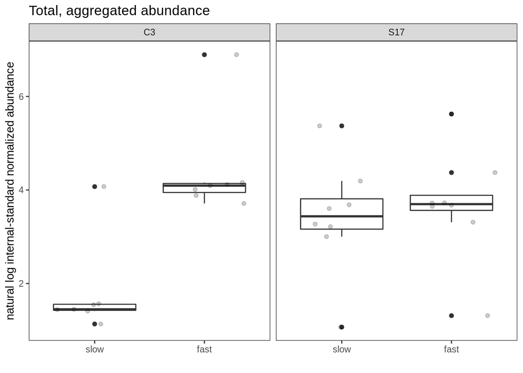

```r
field.group.sum %>%
  ggplot(aes(x=group, y=log(total_abund))) +
  geom_boxplot() +
  geom_jitter(alpha=0.2) +
  facet_wrap(~Soil) +
  labs(title="Total, aggregated abundance", x="", y="natural log internal-standard normalized abundance", color="Block") +
  theme_test()
```

**Statistics**

Linear-mixed effects model.

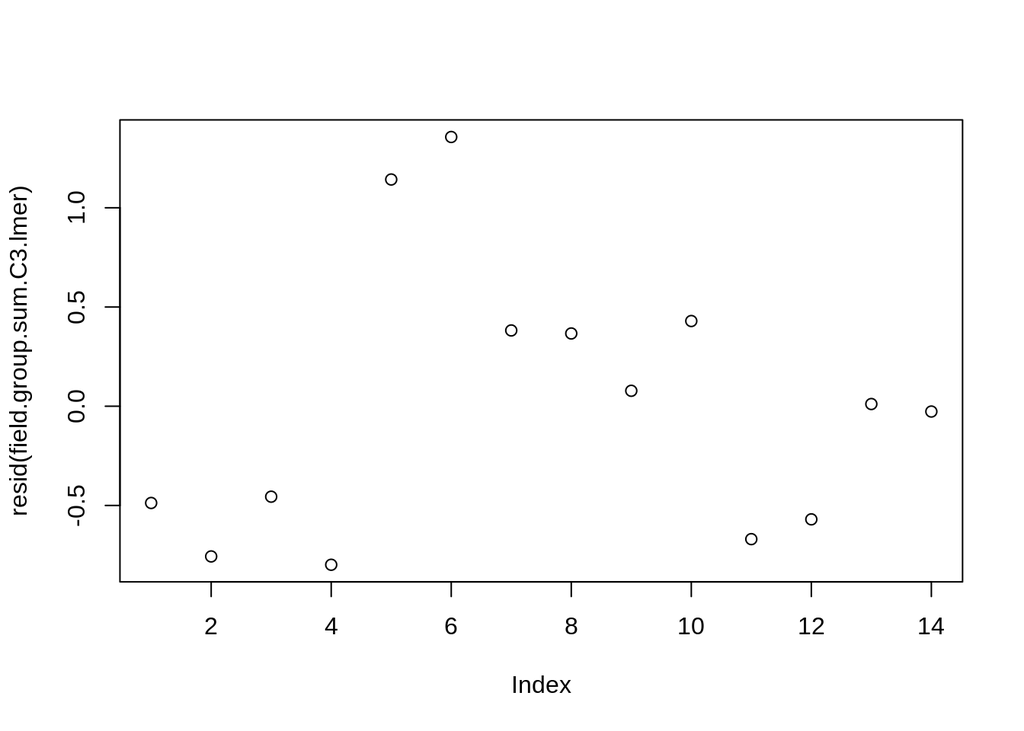

```r
# Cropped
field.group.sum.C3.lmer = lmer(log(total_abund) ~ group + Block + (1|Replicate), data=field.group.sum[field.group.sum$Soil=="C3",]) # fit model
plot(resid(field.group.sum.C3.lmer)) # check normality
```

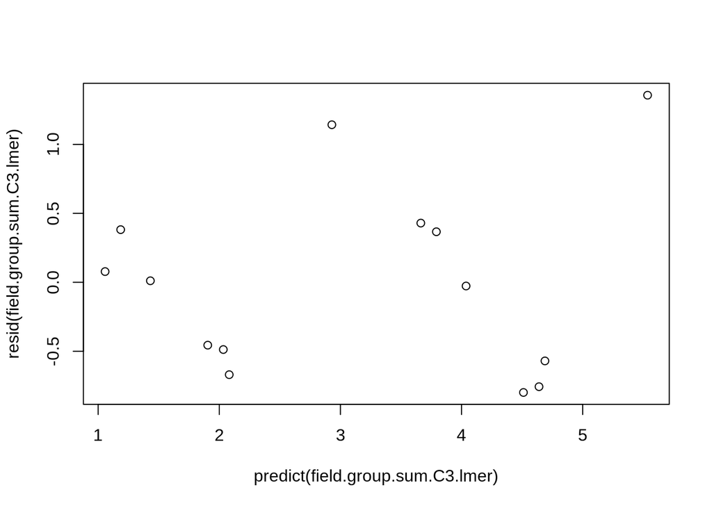

```r
plot(predict(field.group.sum.C3.lmer), resid(field.group.sum.C3.lmer)) # check variances
```

```r
anova(field.group.sum.C3.lmer) # results
```

```
## Type III Analysis of Variance Table with Satterthwaite's method
##        Sum Sq Mean Sq NumDF  DenDF F value    Pr(>F)
## group 23.7801 23.7801     1 8.4216 35.9922 0.0002642 ***
## Block  2.2964  2.2964     1 9.1912  3.4757 0.0944703 .
## ---
## Signif. codes:  0 '***' 0.001 '**' 0.01 '*' 0.05 '.' 0.1 ' ' 1
```

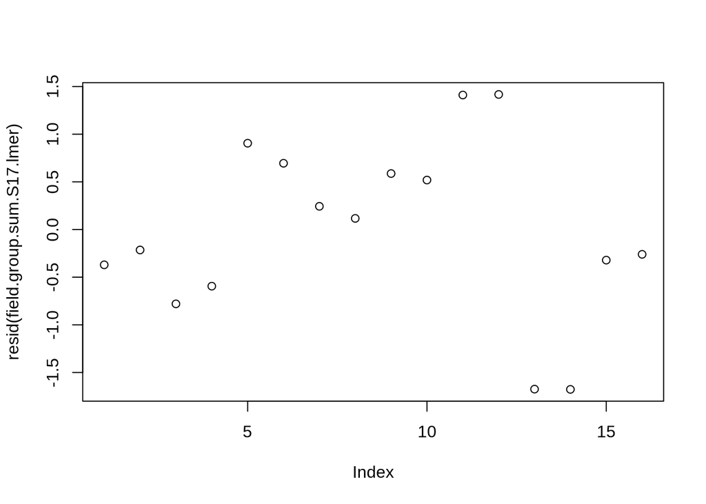

```r
# Successional
field.group.sum.S17.lmer = lmer(log(total_abund) ~ group + Block + (1|Replicate), data=field.group.sum[field.group.sum$Soil=="S17",]) # fit model
plot(resid(field.group.sum.S17.lmer)) # check normality
```

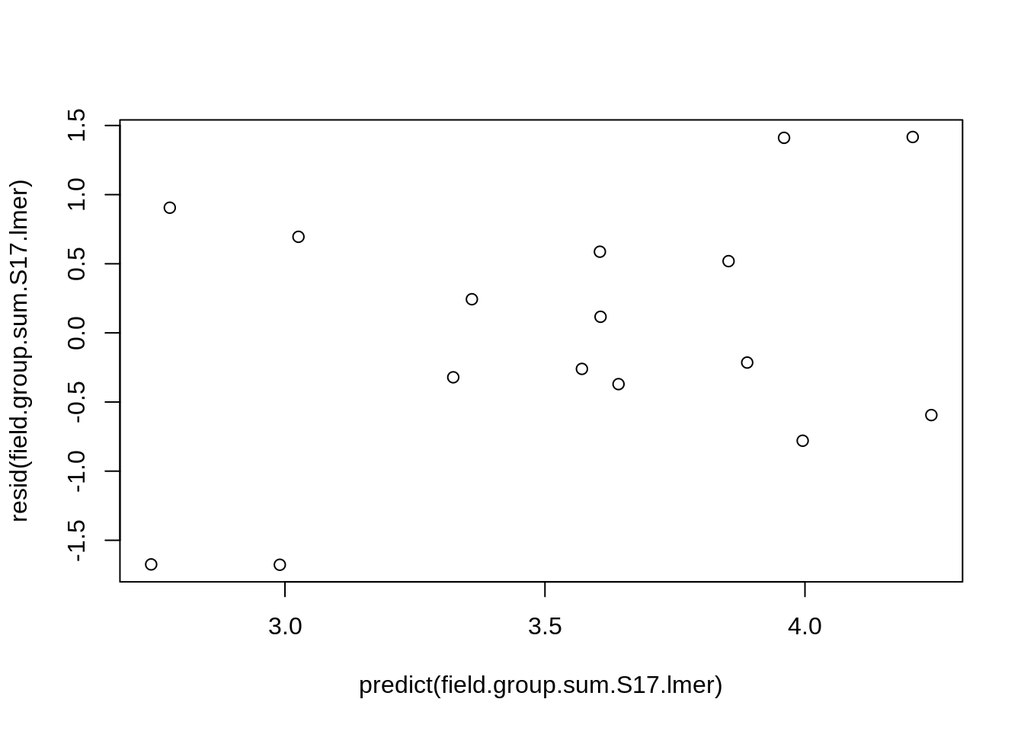

```r
plot(predict(field.group.sum.S17.lmer), resid(field.group.sum.S17.lmer)) # check variances
```

```r
anova(field.group.sum.S17.lmer) # results
```

```
## Type III Analysis of Variance Table with Satterthwaite's method
##         Sum Sq  Mean Sq NumDF DenDF F value Pr(>F)
## group 0.244902 0.244902     1    10  0.2121 0.6550
## Block 0.005137 0.005137     1    10  0.0044 0.9481
```

Conclusion: evidence that, in the cropped soil, ASVs in the “fast” group are, in-total and individually, more abundant than ASVs in the “slow” group. No such evidence in successional soil.